# Political Control w/ Cleaned data

# Origin of Challenge

From https://pen.org/report/banned-usa-growing-movement-to-censor-books-in-schools/#heading-7 Legislative efforts to pass educational “gag orders”; some state legislators proposing or supporting bills that impact the selection and removal of books in school classrooms and libraries

Flordia’s Parental Rights in Education law signed March 2022 - referred to as the “Don’t Say Gay” law

Georgia SB26 passed March 22 makes it easier to remove books with “offensive content”

Tennessee SB2247 makes it easier for books to be banned form studnet access statewide on the basis of challenges filed in individual districts

Utah HB 374 Sensitive Materials in Schools signed into law March 2022 - prohibits sensitive instructura materials considered pornographic or indecent.

Missouri SB 775 - amendment that makes it Class A misdemeanor if person “affiliated with a public or private elementary or secondary school” provides “explicit sexual material” to a student. St. Louis area school districts reacted preemptively by remobing books, especially graphic novels

```r
origin_trends <- new_data %>%
  filter(!is.na(Origin.of.Challenge)) %>%
  group_by(Year, Origin.of.Challenge) %>%
  summarise(X = n(), .groups = "drop") %>%
  arrange(desc(X))

origin_trends
```

```
## # A tibble: 16 × 3
##     Year Origin.of.Challenge                    X
##    <dbl> <chr>                              <int>
##  1  2023 Administration                      8601
##  2  2021 Administrator                       2388
##  3  2023 Formal Challenge                    1522
##  4  2022 Formal Challenge                    1128
##  5  2022 Administration                      1033
##  6  2022 Informal Challenge                   573
##  7  2022 Legislative Action                   432
##  8  2023 Informal Challenge, Administration   373
##  9  2022 Administration/Formal Challenge      355
## 10  2021 Formal Challenge                     143
## 11  2023 Informal Challenge                   127
## 12  2023 Unclear                               97
## 13  2022 Unclear                               37
## 14  2023 Formal Challenge, Administration      20
## 15  2021 Other                                  6
## 16  2023 Administration/Informal Challenge      2
```

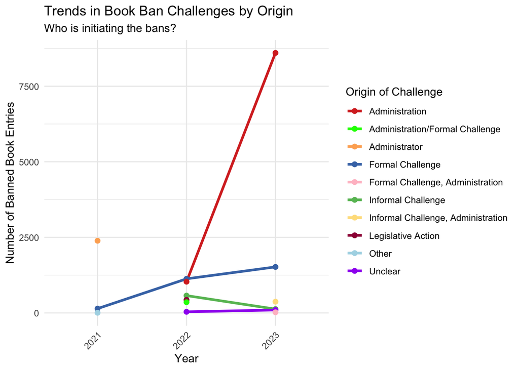

```r
ggplot(origin_trends, aes(x = factor(Year), y = X, color = Origin.of.Challenge, group = Origin.of.Challenge)) +
  geom_line(size = 1.2) +
  geom_point(size = 2) +
   scale_color_manual(
    values = c(
      "Administration" = "#d73027",
      "Formal Challenge" = "#4575b4",
      "Administrator" = "#fdae61",
      "Informal Challenge" = "#66bd63",
      "Informal Challenge, Administration" = "#fee08b",
      "Administration/Formal Challenge" = "green",
      "Legislative Action" = "#9e0142",
      "Administration/Informal Challnge" = "grey",
      "Other"= "lightblue",
      "Unclear" = "purple",
      "Formal Challenge, Administration" = "pink"
    ),
    na.translate = FALSE  # avoid NA color showing up if not desired
  ) +
  labs(
    title = "Trends in Book Ban Challenges by Origin",
    subtitle = "Who is initiating the bans?",
    x = "Year",
    y = "Number of Banned Book Entries",
    color = "Origin of Challenge"
  ) +
  theme_minimal() +
  theme(
    axis.text.x = element_text(angle = 45, hjust = 1),
    legend.position = "right"
  )
```

```r
origin_trends_focus <- new_data %>%
  filter(!is.na(Origin.of.Challenge)) %>%
  mutate(
    Challenge_Type = case_when(
      grepl("Administration|Administrator", Origin.of.Challenge, ignore.case = TRUE) ~ "Administrative",
      grepl("Legislative|Legislature", Origin.of.Challenge, ignore.case = TRUE) ~ "Legislative",
      TRUE ~ NA_character_
    )
  ) %>%
  filter(!is.na(Challenge_Type)) %>%
  group_by(Year, Challenge_Type) %>%
  summarise(Count = n(), .groups = "drop")

origin_trends_focus
```

```
## # A tibble: 4 × 3
##    Year Challenge_Type Count
##   <dbl> <chr>          <int>
## 1  2021 Administrative  2388
## 2  2022 Administrative  1388
## 3  2022 Legislative      432
## 4  2023 Administrative  8996
```

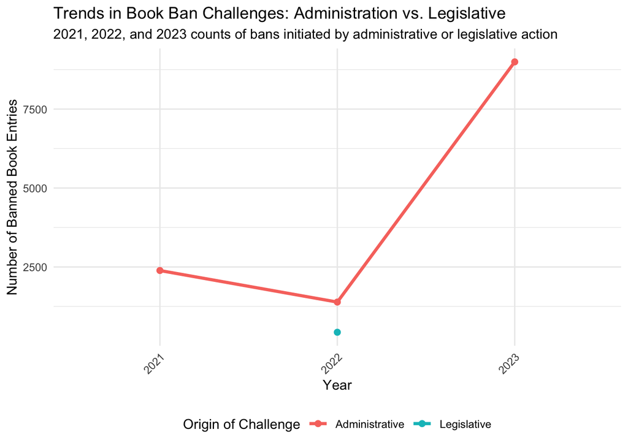

```r
ggplot(origin_trends_focus, aes(x = factor(Year), y = Count, color = Challenge_Type, group = Challenge_Type)) +
  geom_line(size = 1.2) +
  geom_point(size = 2) +
  labs(
    title = "Trends in Book Ban Challenges: Administration vs. Legislative",
    subtitle = "2021, 2022, and 2023 counts of bans initiated by administrative or legislative action",
    x = "Year",
    y = "Number of Banned Book Entries",
    color = "Origin of Challenge"
  ) +
  theme_minimal() +
  theme(axis.text.x = element_text(angle = 45, hjust = 1),
        legend.position = "bottom")
```